# What Makes A "Good" Movie?

[figure not shown]

#### An analysis of movie data from 1916 to 2016 to determine the best way to make a successful movie.

By: Amy Zheng and Daniel Holten

### Introduction:

The movie industry is a multi-billion dollar industry. According to a Deadline article, The U.S. film industry made over $43 billion in revenue in 2017 [1]. Movies bring in a serious amount of money every year but they can be extremely expensive to make, especially if you're shooting a big-budget star-studded, Oscar-worthy film. Producers need to know where to put their money to ensure that their films are a success. But what exactly determines a movie's success? How do we know what a "good" movie is? Well, there's many different ways you can look at how good a movie is. Everyone from film critics to filmmakers, cinephiles to casual movie viewers have their own different ways they determine what a good movie looks like. Some of those factors include: overall popularity, critic ratings, box-office earnings, theater run-time, awards, profit, and reviews.

In this tutorial, we will walk you through how we can use data and analytics to determine what really makes a good movie! Using data to analyze this is a great way to remove the biases that come with movie reviews. Everyone has varying opinions on movies. Just because a movie makes a huge amount of money and is liked by many people does not necessarily mean everyone views it as a "good" movie. Our goal is to determine how to make the best movie possible!

## Outline

1. Getting Started
   - Required Libraries
2. Data Collection
   - 2.1 Raw Data
   - 2.2 Explanation of Data
3. Data Tidying
   - 3.1 Getting Rid of Bad/Unused Data
   - 3.2 Convert Variables into Better Types
   - 3.3 Add More to Data
   - 3.4 Combine Datasets
4. Exploratory Analysis and Data Visualizations
   - 4.1 - Maximums
   - 4.2 - Trends
   - 4.3 - Correlations
5. Machine Learning & Predictive Statistics
6. Conclusion
7. Further Resources
8. References

# Part 1: Getting Started

To start our Notebook, we first import different Python libraries that we will need in our code. A Python library is a collection of functions that allows you to perform many actions without writing your code. The descriptions for each of the libraries we used in this project are seen below.

## Required Libraries

```python
import pandas as pd
import matplotlib.pyplot as plt
from numpy.polynomial.polynomial import polyfit
import numpy as np
import ast, json
import seaborn as sns
import statsmodels.api as sm
from datetime import datetime
from sklearn import linear_model
from sklearn import model_selection
from sklearn.linear_model import LinearRegression
```

- **pandas -** we use Pandas to build a dataframe object that will store our data
- **matplotlib -** we use matplotlib to make our plots. This is extremely important with data visualizations
- **polyfit -** used to find correlation function between two columns of a dataframe
- **numpy -** we use numpy to build arrays, aka lists. The columns and rows of our dataframe can be placed into numpy arrays
- **ast -** this module helps Python applications to process trees of the Python abstract syntax grammar
- **json -** this library is for JSON objects.
- **statsmodels.api -** this library gives us summary statistics for correlation between two variables
- **seaborn -** the Seaborn library is another plotting library, similar to matplotlib
- **datetime -** this module supplies classes for manipulating dates and times
- **sklearn -** this module provides many unsupervised and supervised learning algorithms, particularly for machine learning

# Part 2: Data Collection

### 2.1 Raw Data

Now we have to get our data. The data is stored on our file system as a CSV file, which stands for comma separated values. Before the following code is run, our data is in a file that only consists of text values separated by commas. The pandas (pd) function read_csv() converts this nearly unreadable file into a neat pandas dataframe. This dataframe is extremely easy to see, since it's stored like a table.

```python
credits = pd.read_csv('tmdb_5000_credits.csv')
movies = pd.read_csv('tmdb_5000_movies.csv')
```

### 2.2 Explanation of Data

The dataframe stores information about nearly 5,000 movies. We downloaded it from Kaggle [2], but the data is originally from TMDb. Here's a list of some of the information it stores about the movies:

- title
- budget
- genres
- language
- overview
- release date
- revenue
- runtime

These are stored in varying types, such as numbers, lists, strings, dates, JSON objects

# Part 3: Data Tidying

### 3.1 - Getting Rid of Bad/Unused Data

After you collect your data and get it into a useable format, you want to "clean it." Cleaning data means getting rid of things that you do not need or shouldn't have in your data. It can also mean changing the format of what's stored in your dataframe to a more readable or useable value. Getting rid of unusable datapoints or data we aren't going to use makes traversing through the data frame so much faster because it is smaller.

First, we dropped the columns we knew we weren't planning on using in our analysis (listed in labels). Since this is a rather large dataframe (4803 movies × 20 variables = 96,060 values), dropping 4 columns makes a large impact. Dropping the 4 columns we aren't using decreases our value count by around 19,000 and decreases the size of our dataframe by 1/5.

Next, we remove all rows with missing data in the budget and revenue columns. We cannot do analysis on a row that has missing data. This decreases our # of rows (movies) in our dataframe from 4083 to 3229, getting rid of around 850 unusable datapoints. This decreases our total value count by around 17,000.

Lastly, we discovered that this dataset has the wrong budget for a few movies. Some movies had an extremely low budget in this dataset ($1-$250). We checked the budget for all of these movies on different sites, and there they said the budget was actually much higher. Since the data was wrong we chose to remove them from the dataframe.

After removing unusable datapoints from our dataframe, we decreased our # of datapoints from 96,060 to 51,664. This step shrunk our dataframe by about 46%, decreasing the speed it takes to perform actions on our dataframe.

```python
#dropping irrelevant columns to make our dataset easier to analyze and concise
movies = movies.drop(axis=1, labels=['homepage', 'keywords', 'overview', 'tagline'])

#replacing budget/revenue cells that are 0 with NaN
movies[['budget', 'revenue']] = movies[['budget', 'revenue']].replace(0, np.nan)

#drops budget/revenue columns with missing data - can't do analysis on this
movies.dropna(subset=['budget', 'revenue'], inplace=True)

# This dataset has the wrong budget for a few movies
movies = movies[movies.budget >= 7000]

movies.head()
```

|  | budget | genres | id | original_language | original_title | popularity | production_companies | production_countries | release_date | revenue | runtime | spoken_languages | status | title | vote_average | vote_count |
| --- | --- | --- | --- | --- | --- | --- | --- | --- | --- | --- | --- | --- | --- | --- | --- | --- |
| 0 | 237000000.0 | [{"id": 28, "name": "Action"}, {"id": 12, "nam... | 19995 | en | Avatar | 150.437577 | [{"name": "Ingenious Film Partners", "id": 289... | [{"iso_3166_1": "US", "name": "United States o... | 2009-12-10 | 2.787965e+09 | 162.0 | [{"iso_639_1": "en", "name": "English"}, {"iso... | Released | Avatar | 7.2 | 11800 |
| 1 | 300000000.0 | [{"id": 12, "name": "Adventure"}, {"id": 14, "... | 285 | en | Pirates of the Caribbean: At World's End | 139.082615 | [{"name": "Walt Disney Pictures", "id": 2}, {"... | [{"iso_3166_1": "US", "name": "United States o... | 2007-05-19 | 9.610000e+08 | 169.0 | [{"iso_639_1": "en", "name": "English"}] | Released | Pirates of the Caribbean: At World's End | 6.9 | 4500 |
| 2 | 245000000.0 | [{"id": 28, "name": "Action"}, {"id": 12, "nam... | 206647 | en | Spectre | 107.376788 | [{"name": "Columbia Pictures", "id": 5}, {"nam... | [{"iso_3166_1": "GB", "name": "United Kingdom"... | 2015-10-26 | 8.806746e+08 | 148.0 | [{"iso_639_1": "fr", "name": "Fran\u00e7ais"},... | Released | Spectre | 6.3 | 4466 |
| 3 | 250000000.0 | [{"id": 28, "name": "Action"}, {"id": 80, "nam... | 49026 | en | The Dark Knight Rises | 112.312950 | [{"name": "Legendary Pictures", "id": 923}, {"... | [{"iso_3166_1": "US", "name": "United States o... | 2012-07-16 | 1.084939e+09 | 165.0 | [{"iso_639_1": "en", "name": "English"}] | Released | The Dark Knight Rises | 7.6 | 9106 |
| 4 | 260000000.0 | [{"id": 28, "name": "Action"}, {"id": 12, "nam... | 49529 | en | John Carter | 43.926995 | [{"name": "Walt Disney Pictures", "id": 2}] | [{"iso_3166_1": "US", "name": "United States o... | 2012-03-07 | 2.841391e+08 | 132.0 | [{"iso_639_1": "en", "name": "English"}] | Released | John Carter | 6.1 | 2124 |

## 3.2 Convert Variables into Better Types

As of right now, each column that stores lists (genres, production_companies, production_countries, and spoken_languages) is storing each element as a JSON object. We cannot run analysis on objects (String, boolean, number, ...) so we need to convert them into a useable type. The following code traverses through the lists and removes all the unnecessary information from the JSON object. This leaves us with the actual values we need! For example, for production_countries, we just want a String list of country names. Doing this does exactly that.

Also, this converts the release dates into DateTime object so our dataframe recognizes that it's a date. This way we can organize movies by date and perform analysis on movies by release date.

```python
#parses column and converts it to a list. Gets rid of the id and other random info. associated with the name
def parse_col(column, key):
    for index,i in zip(movies.index, movies[column].apply(json.loads)):
        list1=[]
        for j in range(len(i)):
            list1.append((i[j][key]))
        movies.loc[index,column]=str(list1)

parse_col('genres', 'name')
parse_col('production_companies', 'name')
parse_col('production_countries', 'name')
parse_col('spoken_languages', 'name')
#parse_col('cast', 'name')

#changes release date to DateTime object
movies.release_date = pd.to_datetime(movies['release_date'])

movies.head()
```

|  | budget | genres | id | original_language | original_title | popularity | production_companies | production_countries | release_date | revenue | runtime | spoken_languages | status | title | vote_average | vote_count |
| --- | --- | --- | --- | --- | --- | --- | --- | --- | --- | --- | --- | --- | --- | --- | --- | --- |
| 0 | 237000000.0 | [u'Action', u'Adventure', u'Fantasy', u'Scienc... | 19995 | en | Avatar | 150.437577 | [u'Ingenious Film Partners', u'Twentieth Centu... | [u'United States of America', u'United Kingdom'] | 2009-12-10 | 2.787965e+09 | 162.0 | [u'English', u'Espa\xf1ol'] | Released | Avatar | 7.2 | 11800 |
| 1 | 300000000.0 | [u'Adventure', u'Fantasy', u'Action'] | 285 | en | Pirates of the Caribbean: At World's End | 139.082615 | [u'Walt Disney Pictures', u'Jerry Bruckheimer ... | [u'United States of America'] | 2007-05-19 | 9.610000e+08 | 169.0 | [u'English'] | Released | Pirates of the Caribbean: At World's End | 6.9 | 4500 |
| 2 | 245000000.0 | [u'Action', u'Adventure', u'Crime'] | 206647 | en | Spectre | 107.376788 | [u'Columbia Pictures', u'Danjaq', u'B24'] | [u'United Kingdom', u'United States of America'] | 2015-10-26 | 8.806746e+08 | 148.0 | [u'Fran\xe7ais', u'English', u'Espa\xf1ol', u'... | Released | Spectre | 6.3 | 4466 |
| 3 | 250000000.0 | [u'Action', u'Crime', u'Drama', u'Thriller'] | 49026 | en | The Dark Knight Rises | 112.312950 | [u'Legendary Pictures', u'Warner Bros.', u'DC ... | [u'United States of America'] | 2012-07-16 | 1.084939e+09 | 165.0 | [u'English'] | Released | The Dark Knight Rises | 7.6 | 9106 |
| 4 | 260000000.0 | [u'Action', u'Adventure', u'Science Fiction'] | 49529 | en | John Carter | 43.926995 | [u'Walt Disney Pictures'] | [u'United States of America'] | 2012-03-07 | 2.841391e+08 | 132.0 | [u'English'] | Released | John Carter | 6.1 | 2124 |

## 3.3 Add More to Data

We added three more columns to our dataframe to store additional information we thought would be necessary. One of them is profit. Profit is defined by the Net earnings a movie makes, which is revenue minus budget. This is important information because it helps us identify how successful a movie was in terms of box-office earnings. The higher the profit of a movie, the more successful that movie is seen. Also, we added a category that has each movie's release year. This is important so we can view trends between different years ranges, and notice trends over time. Finally, we added a category for profit margin. This is how well the movie performed at the box office based on it's budget. A profit margin above 1 is great because that means a movie made more money than it cost to make.

```python
#adding profit column = revenue - budget
movies['profit'] = movies['revenue'] - movies['budget']
movies['release_year'] = movies['release_date'].dt.year
movies['profit_margin'] = movies['revenue'] / movies['budget']
movies
```

|  | budget | genres | id | original_language | original_title | popularity | production_companies | production_countries | release_date | revenue | runtime | spoken_languages | status | title | vote_average | vote_count | profit | release_year | profit_margin |
| --- | --- | --- | --- | --- | --- | --- | --- | --- | --- | --- | --- | --- | --- | --- | --- | --- | --- | --- | --- |
| 0 | 237000000.0 | [u'Action', u'Adventure', u'Fantasy', u'Scienc... | 19995 | en | Avatar | 150.437577 | [u'Ingenious Film Partners', u'Twentieth Centu... | [u'United States of America', u'United Kingdom'] | 2009-12-10 | 2.787965e+09 | 162.0 | [u'English', u'Espa\xf1ol'] | Released | Avatar | 7.2 | 11800 | 2.550965e+09 | 2009 | 11.763566 |
| 1 | 300000000.0 | [u'Adventure', u'Fantasy', u'Action'] | 285 | en | Pirates of the Caribbean: At World's End | 139.082615 | [u'Walt Disney Pictures', u'Jerry Bruckheimer ... | [u'United States of America'] | 2007-05-19 | 9.610000e+08 | 169.0 | [u'English'] | Released | Pirates of the Caribbean: At World's End | 6.9 | 4500 | 6.610000e+08 | 2007 | 3.203333 |
| 2 | 245000000.0 | [u'Action', u'Adventure', u'Crime'] | 206647 | en | Spectre | 107.376788 | [u'Columbia Pictures', u'Danjaq', u'B24'] | [u'United Kingdom', u'United States of America'] | 2015-10-26 | 8.806746e+08 | 148.0 | [u'Fran\xe7ais', u'English', u'Espa\xf1ol', u'... | Released | Spectre | 6.3 | 4466 | 6.356746e+08 | 2015 | 3.594590 |
| 3 | 250000000.0 | [u'Action', u'Crime', u'Drama', u'Thriller'] | 49026 | en | The Dark Knight Rises | 112.312950 | [u'Legendary Pictures', u'Warner Bros.', u'DC ... | [u'United States of America'] | 2012-07-16 | 1.084939e+09 | 165.0 | [u'English'] | Released | The Dark Knight Rises | 7.6 | 9106 | 8.349391e+08 | 2012 | 4.339756 |
| 4 | 260000000.0 | [u'Action', u'Adventure', u'Science Fiction'] | 49529 | en | John Carter | 43.926995 | [u'Walt Disney Pictures'] | [u'United States of America'] | 2012-03-07 | 2.841391e+08 | 132.0 | [u'English'] | Released | John Carter | 6.1 | 2124 | 2.413910e+07 | 2012 | 1.092843 |
| 5 | 258000000.0 | [u'Fantasy', u'Action', u'Adventure'] | 559 | en | Spider-Man 3 | 115.699814 | [u'Columbia Pictures', u'Laura Ziskin Producti... | [u'United States of America'] | 2007-05-01 | 8.908716e+08 | 139.0 | [u'English', u'Fran\xe7ais'] | Released | Spider-Man 3 | 5.9 | 3576 | 6.328716e+08 | 2007 | 3.452991 |
| 6 | 260000000.0 | [u'Animation', u'Family'] | 38757 | en | Tangled | 48.681969 | [u'Walt Disney Pictures', u'Walt Disney Animat... | [u'United States of America'] | 2010-11-24 | 5.917949e+08 | 100.0 | [u'English'] | Released | Tangled | 7.4 | 3330 | 3.317949e+08 | 2010 | 2.276134 |
| 7 | 280000000.0 | [u'Action', u'Adventure', u'Science Fiction'] | 99861 | en | Avengers: Age of Ultron | 134.279229 | [u'Marvel Studios', u'Prime Focus', u'Revoluti... | [u'United States of America'] | 2015-04-22 | 1.405404e+09 | 141.0 | [u'English'] | Released | Avengers: Age of Ultron | 7.3 | 6767 | 1.125404e+09 | 2015 | 5.019299 |
| 8 | 250000000.0 | [u'Adventure', u'Fantasy', u'Family'] | 767 | en | Harry Potter and the Half-Blood Prince | 98.885637 | [u'Warner Bros.', u'Heyday Films'] | [u'United Kingdom', u'United States of America'] | 2009-07-07 | 9.339592e+08 | 153.0 | [u'English'] | Released | Harry Potter and the Half-Blood Prince | 7.4 | 5293 | 6.839592e+08 | 2009 | 3.735837 |
| 9 | 250000000.0 | [u'Action', u'Adventure', u'Fantasy'] | 209112 | en | Batman v Superman: Dawn of Justice | 155.790452 | [u'DC Comics', u'Atlas Entertainment', u'Warne... | [u'United States of America'] | 2016-03-23 | 8.732602e+08 | 151.0 | [u'English'] | Released | Batman v Superman: Dawn of Justice | 5.7 | 7004 | 6.232602e+08 | 2016 | 3.493041 |
| 10 | 270000000.0 | [u'Adventure', u'Fantasy', u'Action', u'Scienc... | 1452 | en | Superman Returns | 57.925623 | [u'DC Comics', u'Legendary Pictures', u'Warner... | [u'United States of America'] | 2006-06-28 | 3.910812e+08 | 154.0 | [u'English', u'Fran\xe7ais', u'Deutsch'] | Released | Superman Returns | 5.4 | 1400 | 1.210812e+08 | 2006 | 1.448449 |
| 11 | 200000000.0 | [u'Adventure', u'Action', u'Thriller', u'Crime'] | 10764 | en | Quantum of Solace | 107.928811 | [u'Eon Productions'] | [u'United Kingdom', u'United States of America'] | 2008-10-30 | 5.860907e+08 | 106.0 | [u'English', u'Espa\xf1ol', u'Italiano', u'Fra... | Released | Quantum of Solace | 6.1 | 2965 | 3.860907e+08 | 2008 | 2.930454 |
| 12 | 200000000.0 | [u'Adventure', u'Fantasy', u'Action'] | 58 | en | Pirates of the Caribbean: Dead Man's Chest | 145.847379 | [u'Walt Disney Pictures', u'Jerry Bruckheimer ... | [u'Jamaica', u'United States of America', u'Ba... | 2006-06-20 | 1.065660e+09 | 151.0 | [u'English', u'T\xfcrk\xe7e', u'\u03b5\u03bb\u... | Released | Pirates of the Caribbean: Dead Man's Chest | 7.0 | 5246 | 8.656598e+08 | 2006 | 5.328299 |
| 13 | 255000000.0 | [u'Action', u'Adventure', u'Western'] | 57201 | en | The Lone Ranger | 49.046956 | [u'Walt Disney Pictures', u'Jerry Bruckheimer ... | [u'United States of America'] | 2013-07-03 | 8.928991e+07 | 149.0 | [u'English'] | Released | The Lone Ranger | 5.9 | 2311 | -1.657101e+08 | 2013 | 0.350157 |
| 14 | 225000000.0 | [u'Action', u'Adventure', u'Fantasy', u'Scienc... | 49521 | en | Man of Steel | 99.398009 | [u'Legendary Pictures', u'Warner Bros.', u'DC ... | [u'United Kingdom', u'United States of America'] | 2013-06-12 | 6.628455e+08 | 143.0 | [u'English'] | Released | Man of Steel | 6.5 | 6359 | 4.378455e+08 | 2013 | 2.945980 |
| 15 | 225000000.0 | [u'Adventure', u'Family', u'Fantasy'] | 2454 | en | The Chronicles of Narnia: Prince Caspian | 53.978602 | [u'Walt Disney', u'Walden Media', u'Stillking ... | [u'Czech Republic', u'Poland', u'Slovenia', u'... | 2008-05-15 | 4.196514e+08 | 150.0 | [u'English'] | Released | The Chronicles of Narnia: Prince Caspian | 6.3 | 1630 | 1.946514e+08 | 2008 | 1.865117 |
| 16 | 220000000.0 | [u'Science Fiction', u'Action', u'Adventure'] | 24428 | en | The Avengers | 144.448633 | [u'Paramount Pictures', u'Marvel Studios'] | [u'United States of America'] | 2012-04-25 | 1.519558e+09 | 143.0 | [u'English'] | Released | The Avengers | 7.4 | 11776 | 1.299558e+09 | 2012 | 6.907081 |
| 17 | 380000000.0 | [u'Adventure', u'Action', u'Fantasy'] | 1865 | en | Pirates of the Caribbean: On Stranger Tides | 135.413856 | [u'Walt Disney Pictures', u'Jerry Bruckheimer ... | [u'United States of America'] | 2011-05-14 | 1.045714e+09 | 136.0 | [u'English', u'Espa\xf1ol'] | Released | Pirates of the Caribbean: On Stranger Tides | 6.4 | 4948 | 6.657138e+08 | 2011 | 2.751878 |
| 18 | 225000000.0 | [u'Action', u'Comedy', u'Science Fiction'] | 41154 | en | Men in Black 3 | 52.035179 | [u'Amblin Entertainment', u'Media Magik Entert... | [u'United States of America'] | 2012-05-23 | 6.240268e+08 | 106.0 | [u'English'] | Released | Men in Black 3 | 6.2 | 4160 | 3.990268e+08 | 2012 | 2.773452 |
| 19 | 250000000.0 | [u'Action', u'Adventure', u'Fantasy'] | 122917 | en | The Hobbit: The Battle of the Five Armies | 120.965743 | [u'WingNut Films', u'New Line Cinema', u'Warne... | [u'New Zealand', u'United States of America'] | 2014-12-10 | 9.560198e+08 | 144.0 | [u'English'] | Released | The Hobbit: The Battle of the Five Armies | 7.1 | 4760 | 7.060198e+08 | 2014 | 3.824079 |
| 20 | 215000000.0 | [u'Action', u'Adventure', u'Fantasy'] | 1930 | en | The Amazing Spider-Man | 89.866276 | [u'Columbia Pictures', u'Laura Ziskin Producti... | [u'United States of America'] | 2012-06-27 | 7.522159e+08 | 136.0 | [u'English'] | Released | The Amazing Spider-Man | 6.5 | 6586 | 5.372159e+08 | 2012 | 3.498678 |
| 21 | 200000000.0 | [u'Action', u'Adventure'] | 20662 | en | Robin Hood | 37.668301 | [u'Imagine Entertainment', u'Universal Picture... | [u'United Kingdom', u'United States of America'] | 2010-05-12 | 3.106695e+08 | 140.0 | [u'English', u'\u0e20\u0e32\u0e29\u0e32\u0e44\... | Released | Robin Hood | 6.2 | 1398 | 1.106695e+08 | 2010 | 1.553348 |
| 22 | 250000000.0 | [u'Adventure', u'Fantasy'] | 57158 | en | The Hobbit: The Desolation of Smaug | 94.370564 | [u'WingNut Films', u'New Line Cinema', u'Warne... | [u'New Zealand', u'United States of America'] | 2013-12-11 | 9.584000e+08 | 161.0 | [u'English'] | Released | The Hobbit: The Desolation of Smaug | 7.6 | 4524 | 7.084000e+08 | 2013 | 3.833600 |
| 23 | 180000000.0 | [u'Adventure', u'Fantasy'] | 2268 | en | The Golden Compass | 42.990906 | [u'New Line Cinema', u'Ingenious Film Partners... | [u'United Kingdom', u'United States of America'] | 2007-12-04 | 3.722349e+08 | 113.0 | [u'\xcdslenska', u'English', u'P\u0443\u0441\u... | Released | The Golden Compass | 5.8 | 1303 | 1.922349e+08 | 2007 | 2.067971 |
| 24 | 207000000.0 | [u'Adventure', u'Drama', u'Action'] | 254 | en | King Kong | 61.226010 | [u'WingNut Films', u'Universal Pictures', u'Bi... | [u'New Zealand', u'United States of America', ... | 2005-12-14 | 5.500000e+08 | 187.0 | [u'English'] | Released | King Kong | 6.6 | 2337 | 3.430000e+08 | 2005 | 2.657005 |
| 25 | 200000000.0 | [u'Drama', u'Romance', u'Thriller'] | 597 | en | Titanic | 100.025899 | [u'Paramount Pictures', u'Twentieth Century Fo... | [u'United States of America'] | 1997-11-18 | 1.845034e+09 | 194.0 | [u'English', u'Fran\xe7ais', u'Deutsch', u'sve... | Released | Titanic | 7.5 | 7562 | 1.645034e+09 | 1997 | 9.225171 |
| 26 | 250000000.0 | [u'Adventure', u'Action', u'Science Fiction'] | 271110 | en | Captain America: Civil War | 198.372395 | [u'Studio Babelsberg', u'Marvel Studios', u'Wa... | [u'United States of America'] | 2016-04-27 | 1.153304e+09 | 147.0 | [u'Rom\xe2n\u0103', u'English', u'Deutsch', u'... | Released | Captain America: Civil War | 7.1 | 7241 | 9.033045e+08 | 2016 | 4.613218 |
| 27 | 209000000.0 | [u'Thriller', u'Action', u'Adventure', u'Scien... | 44833 | en | Battleship | 64.928382 | [u'Universal Pictures', u'Hasbro', u'Bluegrass... | [u'United States of America'] | 2012-04-11 | 3.030255e+08 | 131.0 | [u'English', u'\u0e20\u0e32\u0e29\u0e32\u0e44\... | Released | Battleship | 5.5 | 2114 | 9.402548e+07 | 2012 | 1.449883 |
| 28 | 150000000.0 | [u'Action', u'Adventure', u'Science Fiction', ... | 135397 | en | Jurassic World | 418.708552 | [u'Universal Studios', u'Amblin Entertainment'... | [u'United States of America'] | 2015-06-09 | 1.513529e+09 | 124.0 | [u'English'] | Released | Jurassic World | 6.5 | 8662 | 1.363529e+09 | 2015 | 10.090192 |
| 29 | 200000000.0 | [u'Action', u'Adventure', u'Thriller'] | 37724 | en | Skyfall | 93.004993 | [u'Columbia Pictures'] | [u'United Kingdom', u'United States of America'] | 2012-10-25 | 1.108561e+09 | 143.0 | [u'English'] | Released | Skyfall | 6.9 | 7604 | 9.085610e+08 | 2012 | 5.542805 |
| ... | ... | ... | ... | ... | ... | ... | ... | ... | ... | ... | ... | ... | ... | ... | ... | ... | ... | ... | ... |
| 4666 | 225000.0 | [u'Foreign', u'Documentary'] | 139948 | en | Burn | 0.126676 | [u'Apostle Productions'] | [u'United States of America'] | 2012-11-01 | 1.113000e+05 | 86.0 | [u'English'] | Released | Burn | 6.9 | 6 | -1.137000e+05 | 2012 | 0.494667 |
| 4668 | 100000.0 | [u'Comedy'] | 70478 | en | The Stewardesses | 1.183892 | [] | [] | 1969-07-25 | 2.700000e+07 | 69.0 | [] | Released | The Stewardesses | 4.3 | 5 | 2.690000e+07 | 1969 | 270.000000 |
| 4669 | 210000.0 | [u'Adventure', u'Horror', u'Science Fiction'] | 35073 | en | The Beast from 20,000 Fathoms | 2.043661 | [u'Jack Dietz Productions'] | [u'United States of America'] | 1953-06-13 | 5.000000e+06 | 80.0 | [u'English', u'Fran\xe7ais'] | Released | The Beast from 20,000 Fathoms | 6.7 | 41 | 4.790000e+06 | 1953 | 23.809524 |
| 4670 | 400000.0 | [u'Adventure', u'Action', u'Thriller', u'Scien... | 9659 | en | Mad Max | 33.142185 | [u'Kennedy Miller Productions', u'Mad Max Film... | [u'Australia'] | 1979-04-12 | 1.000000e+08 | 93.0 | [u'English'] | Released | Mad Max | 6.6 | 1213 | 9.960000e+07 | 1979 | 250.000000 |
| 4671 | 200000.0 | [u'Comedy', u'Romance'] | 10218 | en | Swingers | 13.971674 | [u'Miramax Films', u'Independent Pictures (II)... | [u'United States of America'] | 1996-10-18 | 4.505922e+06 | 94.0 | [u'English'] | Released | Swingers | 6.8 | 253 | 4.305922e+06 | 1996 | 22.529610 |
| 4672 | 200000.0 | [u'Western'] | 391 | it | Per un pugno di dollari | 38.771062 | [u'United Artists', u'Constantin Film Produkti... | [u'Italy', u'Germany', u'Spain'] | 1964-09-12 | 1.450000e+07 | 99.0 | [u'Italiano', u'Espa\xf1ol'] | Released | A Fistful of Dollars | 7.6 | 883 | 1.430000e+07 | 1964 | 72.500000 |
| 4673 | 200000.0 | [u'Comedy'] | 43595 | en | She Done Him Wrong | 0.622752 | [u'Paramount Pictures'] | [u'United States of America'] | 1933-02-09 | 2.200000e+06 | 66.0 | [u'English'] | Released | She Done Him Wrong | 5.1 | 27 | 2.000000e+06 | 1933 | 11.000000 |
| 4675 | 200000.0 | [u'Drama'] | 54897 | en | The Grace Card | 0.616283 | [u'GraceWorks Pictures'] | [u'United States of America'] | 2011-02-25 | 2.295733e+06 | 101.0 | [u'English'] | Released | The Grace Card | 6.5 | 10 | 2.095733e+06 | 2011 | 11.478665 |
| 4695 | 180000.0 | [u'Drama', u'Comedy', u'Family'] | 21334 | fa | بچه‌های آسمان | 7.072118 | [u'The Institute for the Intellectual Developm... | [u'Iran'] | 1997-08-01 | 9.000000e+05 | 89.0 | [u'\u0641\u0627\u0631\u0633\u06cc'] | Released | Children of Heaven | 7.8 | 112 | 7.200000e+05 | 1997 | 5.000000 |
| 4696 | 8000.0 | [u'Drama', u'Romance'] | 79120 | en | Weekend | 1.041254 | [u'EM Media', u'The Bureau', u'Glendale Pictur... | [u'United Kingdom'] | 2011-09-22 | 4.699470e+05 | 96.0 | [u'English'] | Released | Weekend | 7.4 | 163 | 4.619470e+05 | 2011 | 58.743375 |
| 4700 | 100000.0 | [u'Drama', u'Science Fiction'] | 55420 | en | Another Earth | 25.402697 | [u'Artists Public Domain'] | [u'United States of America'] | 2011-07-22 | 1.776935e+06 | 92.0 | [u'English'] | Released | Another Earth | 6.8 | 527 | 1.676935e+06 | 2011 | 17.769350 |
| 4701 | 150000.0 | [u'Action', u'Drama', u'Romance'] | 5822 | en | Sweet Sweetback's Baadasssss Song | 0.132878 | [u'Yeah'] | [u'United States of America'] | 1971-04-23 | 1.520000e+07 | 97.0 | [u'English'] | Released | Sweet Sweetback's Baadasssss Song | 4.6 | 18 | 1.505000e+07 | 1971 | 101.333333 |
| 4703 | 150000.0 | [u'Comedy', u'Drama', u'Romance'] | 39141 | en | Tadpole | 8.570328 | [u'IFC Productions', u'InDigEnt (Independent D... | [u'United States of America'] | 2002-11-01 | 2.891288e+06 | 78.0 | [u'English', u'Fran\xe7ais'] | Released | Tadpole | 5.5 | 19 | 2.741288e+06 | 2002 | 19.275253 |
| 4704 | 160000.0 | [u'Drama', u'Music', u'Romance'] | 5723 | en | Once | 19.052179 | [u'Summit Entertainment', u'Samson Films', u'R... | [u'Ireland'] | 2007-03-23 | 2.071051e+07 | 85.0 | [u'English'] | Released | Once | 7.3 | 453 | 2.055051e+07 | 2007 | 129.440706 |
| 4713 | 160000.0 | [u'Documentary', u'History'] | 1779 | en | Roger & Me | 3.284903 | [u'Warner Bros.', u'Dog Eat Dog Films'] | [u'United States of America'] | 1989-09-01 | 6.706368e+06 | 91.0 | [u'English'] | Released | Roger & Me | 7.4 | 90 | 6.546368e+06 | 1989 | 41.914800 |
| 4717 | 125000.0 | [u'Drama', u'Comedy'] | 84355 | en | Your Sister's Sister | 12.833247 | [u'Ada Films'] | [u'United States of America'] | 2011-09-11 | 3.200000e+06 | 90.0 | [u'English'] | Released | Your Sister's Sister | 6.5 | 137 | 3.075000e+06 | 2011 | 25.600000 |
| 4720 | 8500000.0 | [u'Drama'] | 339408 | en | The Birth of a Nation | 9.452808 | [u'Phantom Four', u'Mandalay Pictures', u'Bron... | [u'United States of America'] | 2016-09-09 | 1.586157e+07 | 120.0 | [u'English'] | Released | The Birth of a Nation | 6.5 | 178 | 7.361566e+06 | 2016 | 1.866067 |
| 4722 | 100000.0 | [u'Drama'] | 18925 | en | Facing the Giants | 4.563698 | [u'Destination Films'] | [u'United States of America'] | 2006-09-29 | 1.017833e+07 | 111.0 | [u'English'] | Released | Facing the Giants | 6.6 | 64 | 1.007833e+07 | 2006 | 101.783310 |
| 4723 | 100000.0 | [u'Horror', u'Thriller'] | 299245 | en | The Gallows | 18.045782 | [u'New Line Cinema', u'Blumhouse Productions',... | [u'United States of America'] | 2015-07-10 | 4.266441e+07 | 87.0 | [u'English'] | Released | The Gallows | 4.9 | 361 | 4.256441e+07 | 2015 | 426.644100 |
| 4724 | 10000.0 | [u'Drama', u'Fantasy', u'Horror', u'Science Fi... | 985 | en | Eraserhead | 20.399578 | [u'American Film Institute (AFI)', u'Libra Fil... | [u'United States of America'] | 1977-03-19 | 7.000000e+06 | 89.0 | [u'English'] | Released | Eraserhead | 7.5 | 485 | 6.990000e+06 | 1977 | 700.000000 |
| 4738 | 60000.0 | [u'Mystery', u'Drama', u'Thriller'] | 473 | en | Pi | 27.788067 | [u'Truth and Soul Pictures Inc', u'Protozoa Pi... | [u'United States of America'] | 1998-07-10 | 3.221152e+06 | 84.0 | [u'English'] | Released | Pi | 7.1 | 586 | 3.161152e+06 | 1998 | 53.685867 |
| 4742 | 65000.0 | [u'Documentary', u'Comedy', u'Drama'] | 9372 | en | Super Size Me | 10.400603 | [u'Kathbur Pictures'] | [u'United States of America'] | 2004-01-17 | 2.857508e+07 | 100.0 | [u'English'] | Released | Super Size Me | 6.6 | 506 | 2.851008e+07 | 2004 | 439.616585 |
| 4752 | 65000.0 | [u'Romance', u'Comedy', u'Drama'] | 47607 | en | Tiny Furniture | 2.380332 | [u'Tiny Ponies'] | [u'United States of America'] | 2010-11-12 | 4.164980e+05 | 99.0 | [u'English'] | Released | Tiny Furniture | 5.6 | 59 | 3.514980e+05 | 2010 | 6.407662 |
| 4758 | 4000000.0 | [u'Thriller', u'Science Fiction'] | 242095 | en | The Signal | 27.662696 | [u'Automatik Entertainment', u'Low Spark Films... | [u'United States of America'] | 2014-03-15 | 6.008960e+05 | 95.0 | [u'English'] | Released | The Signal | 5.8 | 631 | -3.399104e+06 | 2014 | 0.150224 |
| 4772 | 31192.0 | [u'Drama', u'Action', u'Comedy'] | 42151 | en | Down Terrace | 1.330379 | [] | [u'United Kingdom'] | 2009-09-01 | 1.000000e+04 | 89.0 | [u'English'] | Released | Down Terrace | 6.3 | 26 | -2.119200e+04 | 2009 | 0.320595 |
| 4773 | 27000.0 | [u'Comedy'] | 2292 | en | Clerks | 19.748658 | [u'Miramax Films', u'View Askew Productions'] | [u'United States of America'] | 1994-09-13 | 3.151130e+06 | 92.0 | [u'English'] | Released | Clerks | 7.4 | 755 | 3.124130e+06 | 1994 | 116.708519 |
| 4788 | 12000.0 | [u'Horror', u'Comedy', u'Crime'] | 692 | en | Pink Flamingos | 4.553644 | [u'Dreamland Productions'] | [u'United States of America'] | 1972-03-12 | 6.000000e+06 | 93.0 | [u'English'] | Released | Pink Flamingos | 6.2 | 110 | 5.988000e+06 | 1972 | 500.000000 |
| 4792 | 20000.0 | [u'Crime', u'Horror', u'Mystery', u'Thriller'] | 36095 | ja | キュア | 0.212443 | [u'Daiei Studios'] | [u'Japan'] | 1997-11-06 | 9.900000e+04 | 111.0 | [u'\u65e5\u672c\u8a9e'] | Released | Cure | 7.4 | 63 | 7.900000e+04 | 1997 | 4.950000 |
| 4796 | 7000.0 | [u'Science Fiction', u'Drama', u'Thriller'] | 14337 | en | Primer | 23.307949 | [u'Thinkfilm'] | [u'United States of America'] | 2004-10-08 | 4.247600e+05 | 77.0 | [u'English'] | Released | Primer | 6.9 | 658 | 4.177600e+05 | 2004 | 60.680000 |
| 4798 | 220000.0 | [u'Action', u'Crime', u'Thriller'] | 9367 | es | El Mariachi | 14.269792 | [u'Columbia Pictures'] | [u'Mexico', u'United States of America'] | 1992-09-04 | 2.040920e+06 | 81.0 | [u'Espa\xf1ol'] | Released | El Mariachi | 6.6 | 238 | 1.820920e+06 | 1992 | 9.276909 |

3216 rows × 19 columns

## 3.4 Combine Datasets

Our data came in 2 CSV files, "movies" and "credits." Movies has all the statistical information about a movie. Credits, on the other hand, only stores the movie ID, the title, the cast list, and the crew list. The cast & crew list is extremely large for most movies, so that is why they put it in a separate dataframe. The code below perform a "join" on the two dataframes. This combines them into one based on the title of the film, since each dataframe has the same list of movies. Now we will have all the information on one dataframe.

```python
# joins both datasets
movies = movies.join(credits.set_index('title'), on='original_title')
movies = movies.drop(axis=1, labels=['title']) #redundant column
movies.head()
```

|  | budget | genres | id | original_language | original_title | popularity | production_companies | production_countries | release_date | revenue | ... | spoken_languages | status | vote_average | vote_count | profit | release_year | profit_margin | movie_id | cast | crew |
| --- | --- | --- | --- | --- | --- | --- | --- | --- | --- | --- | --- | --- | --- | --- | --- | --- | --- | --- | --- | --- | --- |
| 0 | 237000000.0 | [u'Action', u'Adventure', u'Fantasy', u'Scienc... | 19995 | en | Avatar | 150.437577 | [u'Ingenious Film Partners', u'Twentieth Centu... | [u'United States of America', u'United Kingdom'] | 2009-12-10 | 2.787965e+09 | ... | [u'English', u'Espa\xf1ol'] | Released | 7.2 | 11800 | 2.550965e+09 | 2009 | 11.763566 | 19995.0 | [{"cast_id": 242, "character": "Jake Sully", "... | [{"credit_id": "52fe48009251416c750aca23", "de... |
| 1 | 300000000.0 | [u'Adventure', u'Fantasy', u'Action'] | 285 | en | Pirates of the Caribbean: At World's End | 139.082615 | [u'Walt Disney Pictures', u'Jerry Bruckheimer ... | [u'United States of America'] | 2007-05-19 | 9.610000e+08 | ... | [u'English'] | Released | 6.9 | 4500 | 6.610000e+08 | 2007 | 3.203333 | 285.0 | [{"cast_id": 4, "character": "Captain Jack Spa... | [{"credit_id": "52fe4232c3a36847f800b579", "de... |
| 2 | 245000000.0 | [u'Action', u'Adventure', u'Crime'] | 206647 | en | Spectre | 107.376788 | [u'Columbia Pictures', u'Danjaq', u'B24'] | [u'United Kingdom', u'United States of America'] | 2015-10-26 | 8.806746e+08 | ... | [u'Fran\xe7ais', u'English', u'Espa\xf1ol', u'... | Released | 6.3 | 4466 | 6.356746e+08 | 2015 | 3.594590 | 206647.0 | [{"cast_id": 1, "character": "James Bond", "cr... | [{"credit_id": "54805967c3a36829b5002c41", "de... |
| 3 | 250000000.0 | [u'Action', u'Crime', u'Drama', u'Thriller'] | 49026 | en | The Dark Knight Rises | 112.312950 | [u'Legendary Pictures', u'Warner Bros.', u'DC ... | [u'United States of America'] | 2012-07-16 | 1.084939e+09 | ... | [u'English'] | Released | 7.6 | 9106 | 8.349391e+08 | 2012 | 4.339756 | 49026.0 | [{"cast_id": 2, "character": "Bruce Wayne / Ba... | [{"credit_id": "52fe4781c3a36847f81398c3", "de... |
| 4 | 260000000.0 | [u'Action', u'Adventure', u'Science Fiction'] | 49529 | en | John Carter | 43.926995 | [u'Walt Disney Pictures'] | [u'United States of America'] | 2012-03-07 | 2.841391e+08 | ... | [u'English'] | Released | 6.1 | 2124 | 2.413910e+07 | 2012 | 1.092843 | 49529.0 | [{"cast_id": 5, "character": "John Carter", "c... | [{"credit_id": "52fe479ac3a36847f813eaa3", "de... |

5 rows × 21 columns

# Part 4: Exploratory Analysis and Data Visualizations

## 4.1 Maximums

### 4.1.1 Top 5 Most Expensive Movies

The most expensive movies between 1916 & 2016

1. Pirates of the Caribbean: On Stranger Tides ------------- 380,000,000 dollars
2. Pirates of the Caribbean: At World's End ---------------- 300,000,000 dollars
3. Avengers: Age of Ultron --------------------------------- 280,000,000 dollars
4. Superman Returns ---------------------------------------- 270,000,000 dollars
5. John Carter --------------------------------------------- 260,000,000 dollars

```python
expensive_movies_df = movies.sort_values(by='budget', ascending=False).head()
expensive_movies_df.original_title
```

```
17    Pirates of the Caribbean: On Stranger Tides
1        Pirates of the Caribbean: At World's End
7                         Avengers: Age of Ultron
10                               Superman Returns
4                                     John Carter
Name: original_title, dtype: object
```

### 4.1.2 Top 5 Highest Grossing Movies

1. Avatar
2. Titanic
3. Jurrasic World
4. Furious 7
5. The Avengers

```python
best_gross_movies_df = movies.sort_values(by='profit', ascending=False).head()
best_gross_movies_df.original_title
```

```
0             Avatar
25           Titanic
28    Jurassic World
44         Furious 7
16      The Avengers
Name: original_title, dtype: object
```

### 4.1.3 Top 5 Most Profitable Movies

The highest profit margin of movies between 1916 & 2016:

1. Paranormal Activity
2. The Blair Witch Project
3. Eraserhead
4. Pink Flamingos
5. Super Size Me

```python
profitable_movies_df = movies.sort_values(by='profit_margin', ascending=False).head()
profitable_movies_df.original_title
```

```
4577        Paranormal Activity
4496    The Blair Witch Project
4724                 Eraserhead
4788             Pink Flamingos
4742              Super Size Me
Name: original_title, dtype: object
```

### 4.1.4 Top 5 Most Popular Movies

(popularity ratings are based on user votes on TMDb's website)  
The highest rated movies between 1916 & 2016:

1. Minions
2. Interstellar
3. Deadpool
4. Guardians of the Galaxy
5. Mad Max: Fury Road

```python
popular_movies_df = movies.sort_values(by='popularity', ascending=False).head()
popular_movies_df.original_title
```

```
546                    Minions
95                Interstellar
788                   Deadpool
94     Guardians of the Galaxy
127         Mad Max: Fury Road
Name: original_title, dtype: object
```

## 4.2 Trends

### 4.2.1 Movie Ratings Over Time: Have they been getting better over the years?

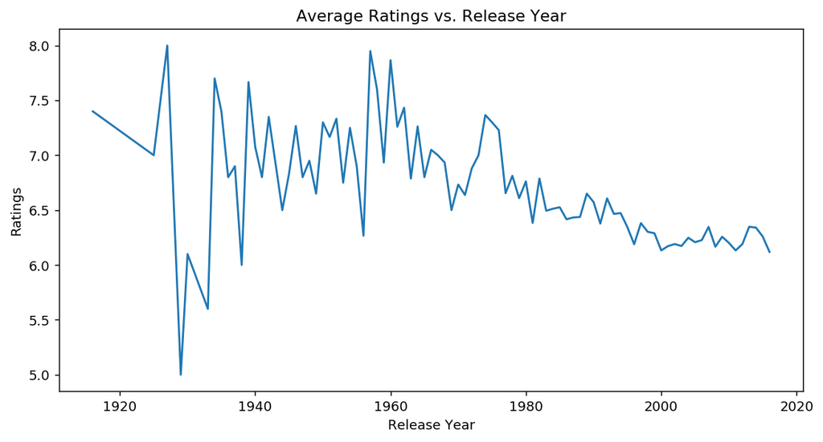

```python
rating_year = movies.groupby('release_year')['vote_average'].mean()

#figure size(width, height)
plt.figure(figsize=(10,5), dpi = 130)

#on x-axis
plt.xlabel('Release Year', fontsize = 10)
#on y-axis
plt.ylabel('Ratings', fontsize = 10)
#title of the line plot
plt.title('Average Ratings vs. Release Year')

#plotting the graph
plt.plot(rating_year)

#displaying the line plot
plt.show()
```

### Analysis

The overall trend in the data shows that overtime, the average ratings of movies has been decreasing since about 1960. However, there was a large spike in the late 70s. Although this may look like the overall quality of movies is decreasing, that's not entirely true. People are still going to the movies, enjoying them, and rating them highly. So you might be asking yourself... then why does the average rating of a movie keep decreasing over time?

That's because the number of movies being rated is also increasing every year. As seen in the graph below, the number of ratings is extremely low for movies that were released from 1920 to 1980. Around 1990, the number of ratings started to skyrocket. With more and more ratings every year, its harder for the average rating to be as high as it used to be.

1927 is the year with the highest average rating of movies. However, there are only 657 ratings entered in TMDb's website for movies released that year. That's significantly less than the 200,000 ratings on the site for 2015 films.

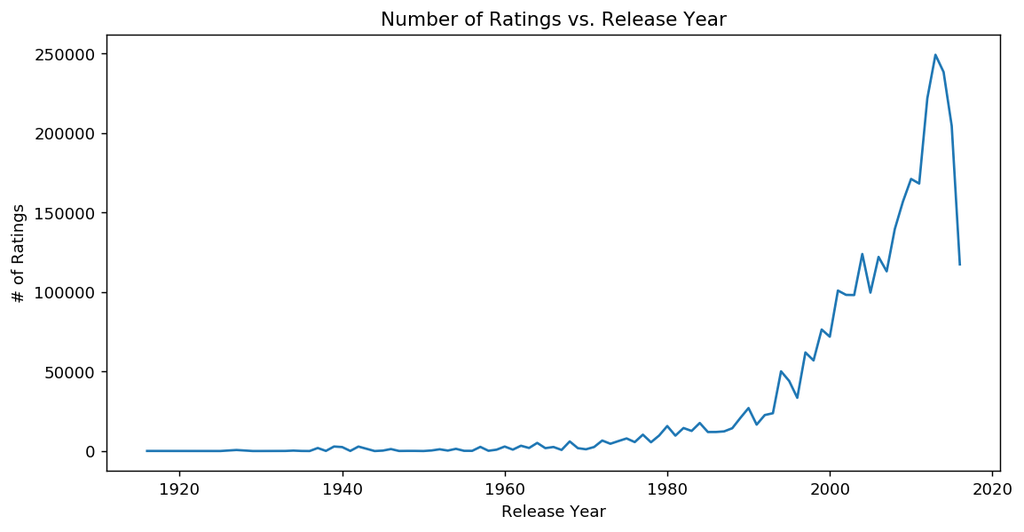

```python
ratings_per_year = movies.groupby('release_year')['vote_count'].sum()

#figure size(width, height)
plt.figure(figsize=(10,5), dpi = 130)

#on x-axis
plt.xlabel('Release Year', fontsize = 10)
#on y-axis
plt.ylabel('# of Ratings', fontsize = 10)
#title of the line plot
plt.title('Number of Ratings vs. Release Year')

#plotting the graph
plt.plot(ratings_per_year)

#displaying the line plot
plt.show()
```

## 4.3 Correlations

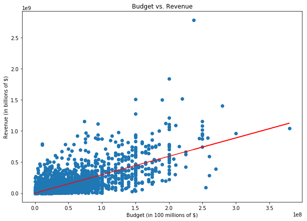

```
2.9598156508674047
                            OLS Regression Results
==============================================================================
Dep. Variable:                revenue   R-squared:                       0.496
Model:                            OLS   Adj. R-squared:                  0.496
Method:                 Least Squares   F-statistic:                     3168.
Date:                Mon, 16 Dec 2019   Prob (F-statistic):               0.00
Time:                        14:39:55   Log-Likelihood:                -64746.
No. Observations:                3218   AIC:                         1.295e+05
Df Residuals:                    3216   BIC:                         1.295e+05
Df Model:                           1
Covariance Type:            nonrobust
==============================================================================
                 coef    std err          t      P>|t|      [0.025      0.975]
------------------------------------------------------------------------------
const       9.852e+05   3.17e+06      0.311      0.756   -5.23e+06     7.2e+06
budget         2.9598      0.053     56.287      0.000       2.857       3.063
==============================================================================
Omnibus:                     2512.072   Durbin-Watson:                   1.501
Prob(Omnibus):                  0.000   Jarque-Bera (JB):           126724.574
Skew:                           3.264   Prob(JB):                         0.00
Kurtosis:                      33.042   Cond. No.                     8.19e+07
==============================================================================

Warnings:
[1] Standard Errors assume that the covariance matrix of the errors is correctly specified.
[2] The condition number is large, 8.19e+07. This might indicate that there are
strong multicollinearity or other numerical problems.
```

```python
#Scatter plot on how budget and revenue are related

x = movies['budget']
y = movies['revenue']
plt.figure(figsize=(10,7))
plt.scatter(x, y)
plt.xlabel('Budget (in 100 millions of $)')
plt.ylabel('Revenue (in billions of $)')
plt.title('Budget vs. Revenue')


b, m = polyfit(x, y, 1)
plt.plot(x, b + m * x, 'r-')
plt.show()
print(m)
results = sm.OLS(y,sm.add_constant(x)).fit()
print(results.summary())
```

### 4.3.2 Profit v. Rating: Does a movie doing well at the box-office correlate with peoples opinions about it?

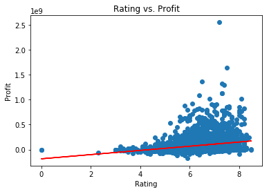

```
41948315.80956504
                            OLS Regression Results
==============================================================================
Dep. Variable:                 profit   R-squared:                       0.054
Model:                            OLS   Adj. R-squared:                  0.053
Method:                 Least Squares   F-statistic:                     181.8
Date:                Mon, 16 Dec 2019   Prob (F-statistic):           2.41e-40
Time:                        14:39:55   Log-Likelihood:                -65236.
No. Observations:                3218   AIC:                         1.305e+05
Df Residuals:                    3216   BIC:                         1.305e+05
Df Model:                           1
Covariance Type:            nonrobust
================================================================================
                   coef    std err          t      P>|t|      [0.025      0.975]
--------------------------------------------------------------------------------
const        -1.837e+08   1.98e+07     -9.269      0.000   -2.23e+08   -1.45e+08
vote_average  4.195e+07   3.11e+06     13.483      0.000    3.58e+07     4.8e+07
==============================================================================
Omnibus:                     2896.962   Durbin-Watson:                   1.021
Prob(Omnibus):                  0.000   Jarque-Bera (JB):           148727.994
Skew:                           4.120   Prob(JB):                         0.00
Kurtosis:                      35.270   Cond. No.                         47.6
==============================================================================

Warnings:
[1] Standard Errors assume that the covariance matrix of the errors is correctly specified.
```

```python
#Scatter plot on how profit and rating are related
x = movies['vote_average']
y = movies['profit']

plt.scatter(x, y)
plt.xlabel('Rating')
plt.ylabel('Profit')
plt.title('Rating vs. Profit')

b, m = polyfit(x, y, 1)
plt.plot(x, b + m * x, 'r-')
plt.show()
print(m)
results = sm.OLS(y,sm.add_constant(x)).fit()
print(results.summary())
```

### 4.3.3 Genre Analysis: Do people favor certain genres over others?

```python
# formatting the data in the genres columns.
movies['genres']=movies['genres'].str.strip('[]').str.replace(' ','').str.replace("'",'')
movies['genres']=movies['genres'].str.split(',')
```

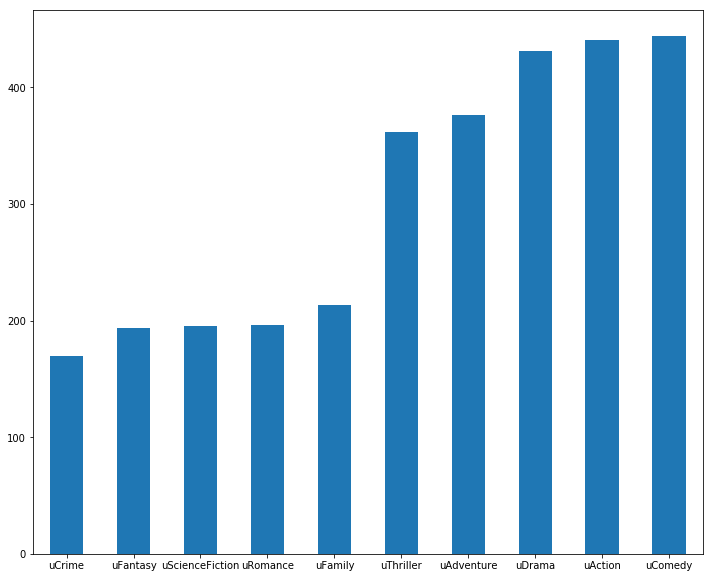

```python
#selecting the movies having profit $50M or more
high_profits = movies[movies['profit'] >= 50000000]

#reindexing new data
high_profits.index = range(len(high_profits))

#we will start from 1 instead of 0
high_profits.index = high_profits.index + 1

plt.subplots(figsize=(12,10))
list1=[]

# extending the list of genres to collect all the genres of all the profitable movies
for i in high_profits['genres']:
    list1.extend(i)

genre_count_series = pd.Series(list1).value_counts()[:10].sort_values(ascending=True)

ax = genre_count_series.plot.bar(x='Genre', y='Profit', rot=0)
```

### 4.3.4 Revenue vs. Runtime: Do longer movies make more money?

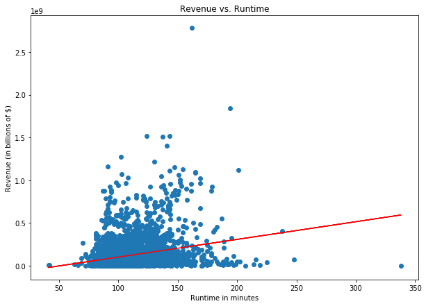

```
2070301.5449886378
                            OLS Regression Results
==============================================================================
Dep. Variable:                revenue   R-squared:                       0.054
Model:                            OLS   Adj. R-squared:                  0.054
Method:                 Least Squares   F-statistic:                     183.6
Date:                Mon, 16 Dec 2019   Prob (F-statistic):           1.02e-40
Time:                        14:39:55   Log-Likelihood:                -65760.
No. Observations:                3218   AIC:                         1.315e+05
Df Residuals:                    3216   BIC:                         1.315e+05
Df Model:                           1
Covariance Type:            nonrobust
==============================================================================
                 coef    std err          t      P>|t|      [0.025      0.975]
------------------------------------------------------------------------------
const      -1.076e+08   1.72e+07     -6.244      0.000   -1.41e+08   -7.38e+07
runtime      2.07e+06   1.53e+05     13.550      0.000    1.77e+06    2.37e+06
==============================================================================
Omnibus:                     2545.148   Durbin-Watson:                   0.841
Prob(Omnibus):                  0.000   Jarque-Bera (JB):            76832.098
Skew:                           3.539   Prob(JB):                         0.00
Kurtosis:                      25.867   Cond. No.                         607.
==============================================================================

Warnings:
[1] Standard Errors assume that the covariance matrix of the errors is correctly specified.
```

```python
#Scatter plot on how runtime and revenue are related

x = movies['runtime']
y = movies['revenue']
plt.figure(figsize=(10,7))
plt.scatter(x, y)
plt.xlabel('Runtime in minutes')
plt.ylabel('Revenue (in billions of $)')
plt.title('Revenue vs. Runtime')


b, m = polyfit(x, y, 1)
plt.plot(x, b + m * x, 'r-')
plt.show()
print(m)
results = sm.OLS(y,sm.add_constant(x)).fit()
print(results.summary())
```

# Part 5: Machine Learning and Predictive Statistics

Now, we will use Machine Learning to determine which factors of a movie impact a movie's success (revenue). Here, we are using Linear Regression (Ordinary Least Squares) to make our predictions. We will be analyzing budget, popularity, release year, runtime, and vote average since all these values are numerical and will be easier to work with. In our previous section, we noticed many of these values have an impact on how much revenue a movie makes.

```python
X = movies[['budget', 'popularity', 'release_year','runtime','vote_average']]
X_OLS = sm.add_constant(X)
y = movies[['revenue']]


model = sm.OLS(y, X_OLS)
results = model.fit()
results.summary()
```

OLS Regression Results

| Dep. Variable: | revenue | R-squared: | 0.618 |
| --- | --- | --- | --- |
| Model: | OLS | Adj. R-squared: | 0.618 |
| Method: | Least Squares | F-statistic: | 1041. |
| Date: | Mon, 16 Dec 2019 | Prob (F-statistic): | 0.00 |
| Time: | 14:46:51 | Log-Likelihood: | -64300. |
| No. Observations: | 3218 | AIC: | 1.286e+05 |
| Df Residuals: | 3212 | BIC: | 1.286e+05 |
| Df Model: | 5 |  |  |
| Covariance Type: | nonrobust |  |  |

|  | coef | std err | t | P>\|t\| | [0.025 | 0.975] |
| --- | --- | --- | --- | --- | --- | --- |
| const | 1.037e+09 | 3.38e+08 | 3.066 | 0.002 | 3.74e+08 | 1.7e+09 |
| budget | 2.4309 | 0.055 | 44.448 | 0.000 | 2.324 | 2.538 |
| popularity | 1.699e+06 | 6.66e+04 | 25.517 | 0.000 | 1.57e+06 | 1.83e+06 |
| release_year | -5.998e+05 | 1.67e+05 | -3.595 | 0.000 | -9.27e+05 | -2.73e+05 |
| runtime | -6.02e+04 | 1.11e+05 | -0.544 | 0.586 | -2.77e+05 | 1.57e+05 |
| vote_average | 2.274e+07 | 2.71e+06 | 8.387 | 0.000 | 1.74e+07 | 2.81e+07 |

| Omnibus: | 2513.456 | Durbin-Watson: | 1.564 |
| --- | --- | --- | --- |
| Prob(Omnibus): | 0.000 | Jarque-Bera (JB): | 204729.538 |
| Skew: | 3.094 | Prob(JB): | 0.00 |
| Kurtosis: | 41.582 | Cond. No. | 1.00e+10 |

Warnings:  
[1] Standard Errors assume that the covariance matrix of the errors is correctly specified.  
[2] The condition number is large, 1e+10. This might indicate that there are  
strong multicollinearity or other numerical problems.

### Analysis

By looking at our p-values we can see that budget, popularity, release year, and vote_average are all significant values, whereas runtime is not. This aligns with our discoveries in the previous section, where we noticed runtime does not have a huge correlation with revenue.

```python
X = movies[['budget', 'popularity','release_year', 'vote_average']]
y = movies[['revenue']]

#Train and fit the model
lm = linear_model.LinearRegression()
model = lm.fit(X,y)
coefficients = lm.coef_
print('Budget coeff = ' + str(coefficients[0][0]))
print('Popularity coeff = ' + str(coefficients[0][1]))
print('Release year coeff = ' + str(coefficients[0][2]))
print('Vote Average coeff = ' + str(coefficients[0][3]))
print('R^2 Value = ' + str(lm.score(X,y)))
```

```
Budget coeff = 2.4225356873541872
Popularity coeff = 1699954.4334229892
Release year coeff = -583795.5774323955
Vote Average coeff = 22212711.09827564
R^2 Value = 0.6182537643388127
```

After performing linear regression on our 4 most significant values, we get a R^2 value of 0.618. This means a little less than 40% of our data is residing in the residual, meaning most of our data fits our prediction.

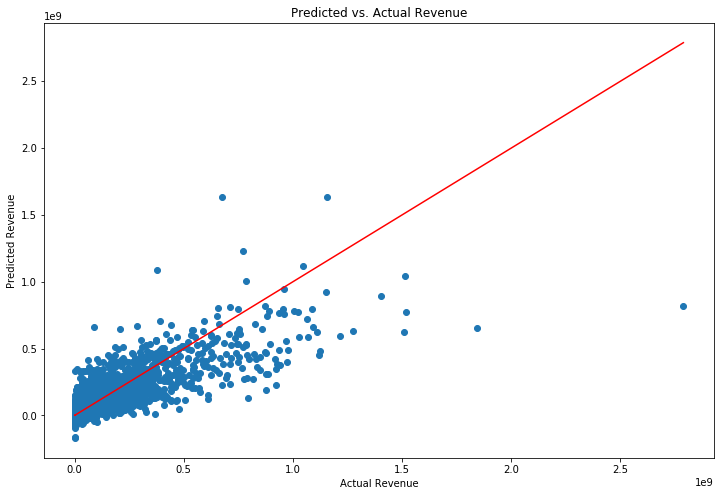

```python
pred = model.predict(X)

plt.figure(figsize=(12,8))
plt.title("Predicted vs. Actual Revenue", fontsize=12)
plt.scatter(y,pred)
plt.plot(y, y, color = "Red")
plt.xlabel("Actual Revenue")
plt.ylabel("Predicted Revenue")
plt.show()
```

We can see that the model generally follows the trend of the actual revenue.

# Part 6: Conclusion

We our our tutorial provided you with a clear understanding of data curation/parsing, data analysis, and machine learning in order to determine what factors of a movie impact its success!

# Part 7: Further Resources

Further details about all the packages and resources we used are listed below. Consult these pages for a deeper understanding!

- **sklearn -** http://scikit-learn.org
- **pandas -** https://pandas.pydata.org/pandas-docs/stable/getting_started/tutorials.html
- **matplotlib -** https://matplotlib.org/
- **numpy -** https://numpy.org/
- **seaborn -** https://seaborn.pydata.org/

# Part 8: References

[1] https://deadline.com/2018/07/film-industry-revenue-2017-ibisworld-report-gloomy-box-office-1202425692/

[2] https://www.kaggle.com/tmdb/tmdb-movie-metadata